[figure not shown]

FU(STI)-2

General Description

FUEL INJECTION (FUEL SYSTEMS)

1. General Description

A: SPECIFICATION

Fuel tank

Capacity 60 L (15.9 US gal, 13.2 Imp gal)

Location Under rear seat

Fuel pump

Type Impeller

2

, 130.5 psi) or less

Discharge rate

175 L (46.2 US gal, 38.5 Imp gal)/h or more

2

, 43.5 psi)]

Fuel filter In-tank type

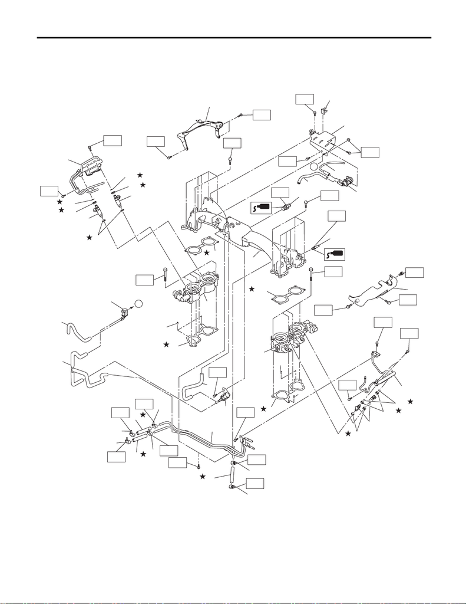

FU(STI)-3

General Description

FUEL INJECTION (FUEL SYSTEMS)

B: COMPONENT

1. INTAKE MANIFOLD

(2)

(2)

(3)

(3)

(1)

(5)

(2)

(3)

(4)

(14)

(11)

(12)

(20)

(8)

(7)

(17)

(18)

(7)

(10)

(10)

(11)

(12)

(8)

(9)

(15)

(19)

(22)

(8)

(21)

(26)

(25)

(16)

(9)

(11)

T5

T5

T2

T3

T5

T2

T4

T3

T6

T6

T1

T2

T1

T5

T5

T5

T5

T5

T6

(13)

T5

T5

T5

(23)

(6)

(24)

T2

T2

A

A

T1

T1

T1

(3)

(3)

T1

(3)

(27)

(28)

(27)

(28)

(27)

(28)

FU-08463

[figure not shown]

FU(STI)-4

General Description

FUEL INJECTION (FUEL SYSTEMS)

(1) Fuel pipe ASSY (13) Fuel injector pipe RH (25) Vacuum hose

(2) Fuel hose (14) Fuel injector pipe LH (26) Air control hose

(3) Clamp (15) Fuel pipe protector RH (27) O-ring

(4) Purge control solenoid valve 1 (16) Fuel pipe protector LH (28) Rubber

(5) Vacuum hose A (17) Solenoid valve bracket

(6) Vacuum control hose (18) Intake manifold Tightening torque: N·m (kgf-m, ft-lb)

(7) Intake manifold gasket (19) Wastegate control solenoid valve T1: 1.25 (0.1, 0.9)

(8) Guide pin (20) Nipple T2: 6.4 (0.7, 4.7)

(9) Tumble generator valve ASSY (21) Nipple T3: 8.3 (0.8, 6.1)

(10) Tumble generator valve gasket (22) Clip T4: 17 (1.7, 12.5)

(11) Fuel injector (23) Purge control solenoid valve 2 T5: 19 (1.9, 14.0)

(12) Seal ring (24) Vacuum hose T6: 25 (2.5, 18.4)

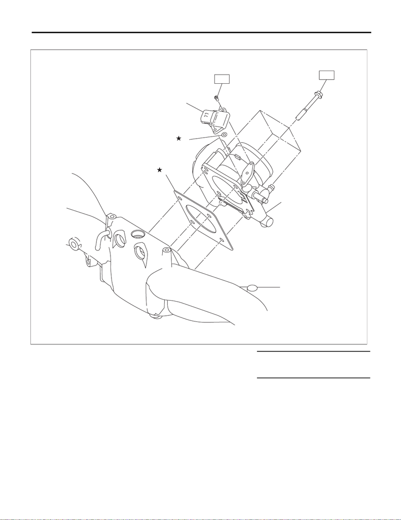

FU(STI)-5

General Description

FUEL INJECTION (FUEL SYSTEMS)

2. AIR INTAKE SYSTEM

(1) Gasket (3) Manifold absolute pressure sensor Tightening torque: N·m (kgf-m, ft-lb)

(2) Throttle body (4) O-ring T1: 2 (0.2, 1.5)

T2: 8 (0.8, 5.9)

FU-05680

T1

T2

(1)

(3)

(2)

(4)

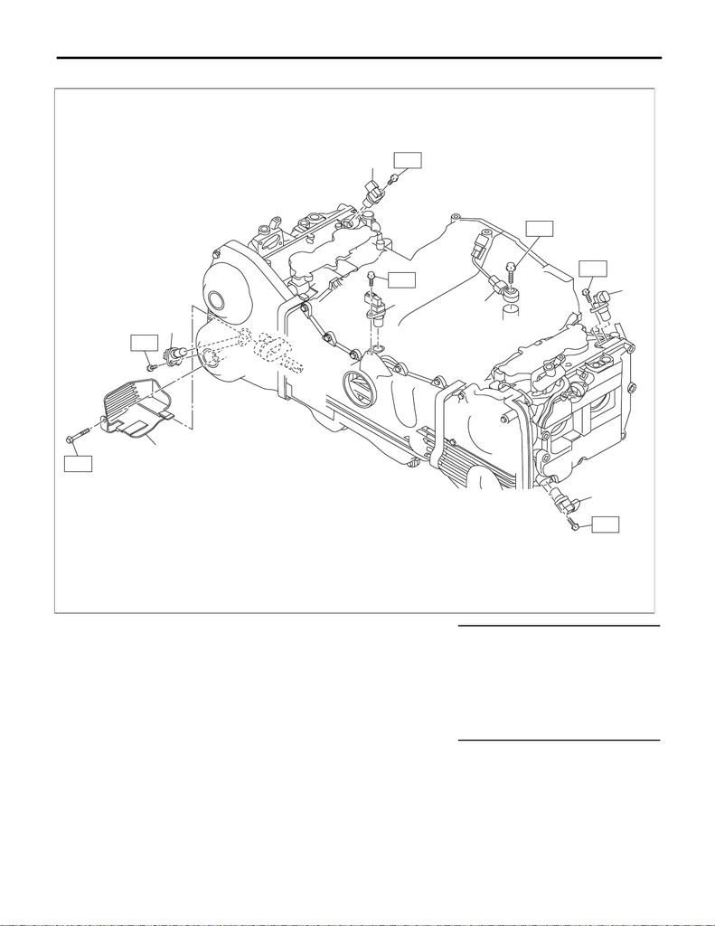

FU(STI)-6

General Description

FUEL INJECTION (FUEL SYSTEMS)

3. CRANKSHAFT POSITION, CAMSHAFT POSITION AND KNOCK SENSORS

(1) Crankshaft position sensor (5) Exhaust camshaft position sensor

LH

Tightening torque: N·m (kgf-m, ft-lb)

(2) Knock sensor (6) Exhaust camshaft position sensor

RH

T1: 5 (0.5, 3.7)

(3) Intake camshaft position sensor

LH

(7) Engine harness cover T2: 6.4 (0.7, 4.7)

(4) Intake camshaft position sensor

RH

T3: 24 (2.4, 17.7)

FU-05850

T2

T2

T3

T2

T2

T1

T2

(7)

(6)

(5)

(2)

(3)

(1)

(4)

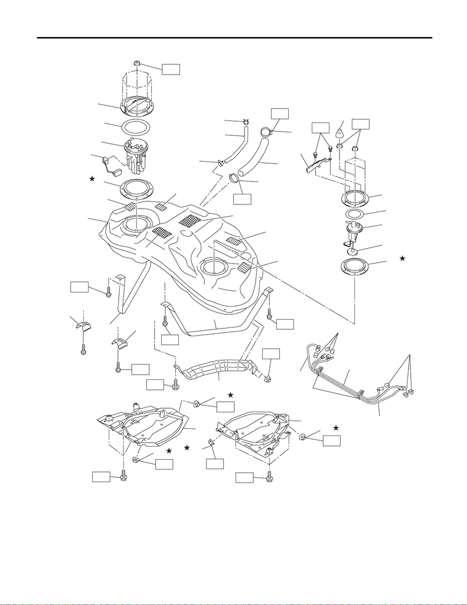

FU(STI)-7

General Description

FUEL INJECTION (FUEL SYSTEMS)

4. FUEL TANK

FU-08387

T5

T5

T4

T5

(2)

(2)

(15)

(10)

(13)

(12)

(1)

(7)

T7

(14)

(11)

(20)

T7

(9)

(21)

(22)

(23)

T1

T2

(24)

(25)

(25)

(28)

(29)

(31)

(29)

(30)

(31)

(30)

(4)

(33)

(32)

(3)

(33)

(26)

T4

(16)

T4

T4

(17)

T4

T3

T3

T3

T3

(18)

(19)

(19)

(19)

(19)

(5)

(8)

(27)

T6

(6)

[figure not shown]

FU(STI)-8

General Description

FUEL INJECTION (FUEL SYSTEMS)

(1) Fuel tank (15) Stopper LH (29) Cushion

(2) Fuel tank band (16) Heat shield cover (30) Cushion

(3) Fuel delivery tube (17) Fuel tank protector RH (31) Cushion

(4) Jet pump tube (18) Fuel tank protector LH (32) Return tube

(5) Fuel pump ASSY (19) Self-locking nut (33) Retainer

(6) Fuel pump upper plate (20) Rubber cap

(7) Fuel pump gasket (21) Fuel filler hose Tightening torque: N·m (kgf-m, ft-lb)

(8) Fuel level sensor (22) Clamp T1: 2 (0.2, 1.5)

(9) Fuel sub level sensor (23) Clamp T2: 2.5 (0.3, 1.8)

(10) Fuel sub level sensor upper plate (24) Evaporation hose T3: 9 (0.9, 6.6)

(11) Fuel sub level sensor gasket (25) Clip T4: 18 (1.8, 13.3)

(12) Fuel sub level sensor filter (26) Tube clamp T5: <Ref. to FU(w/o STI)-157,

INSTALLATION, Fuel Tank.>

(13) Fuel sub level sensor protector (27) Fuel pump upper plate cushion T6: <Ref. to FU(w/o STI)-171,

INSTALLATION, Fuel Pump.>

(14) Stopper RH (28) Fuel sub level sensor upper plate

cushion

T7: <Ref. to FU(w/o STI)-180,

INSTALLATION, Fuel Sub Level

Sensor.>

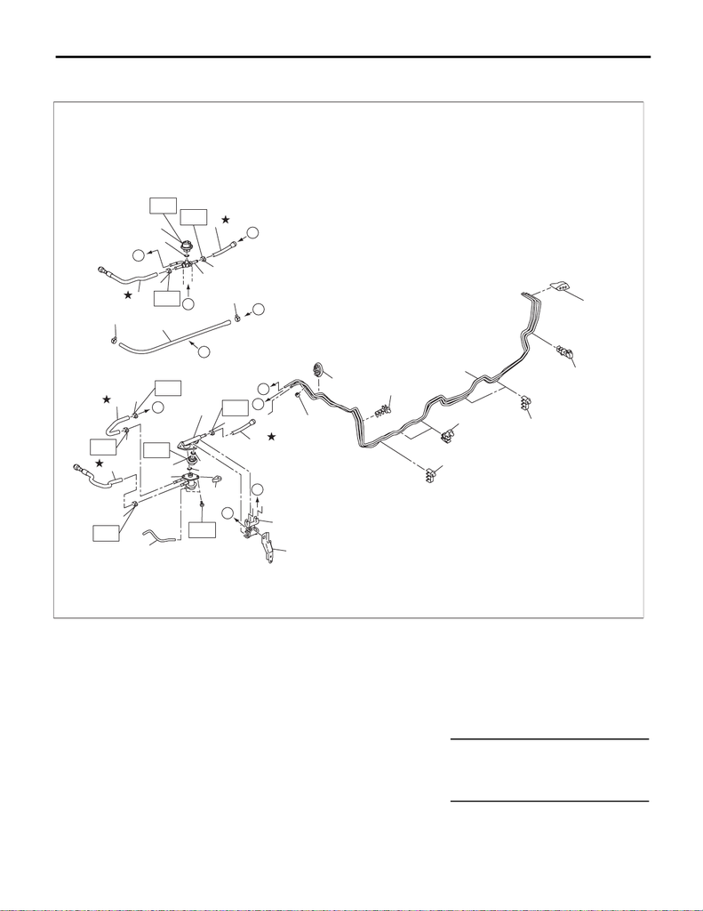

FU(STI)-9

General Description

FUEL INJECTION (FUEL SYSTEMS)

5. FUEL LINE

• Fuel line 1

(1) Fuel delivery hose A (12) Pressure regulator (23) Pipe clamp

(2) Clamp (13) Fuel pipe protector (24) Pipe clamp

(3) Pulsation damper A (14) O-ring (25) Pipe clamp

(4) Fuel pipe gasket (15) Pulsation damper B (26) Pipe clamp

(5) Fuel by-pass pipe (16) Fuel holder ASSY (27) Pipe clamp

(6) Fuel delivery hose B (17) Hose clamp (28) Fuel pipe rear grommet

(7) Clip (18) Hose clamp bracket

(8) Evaporation hose (19) Fuel return hose B Tightening torque: N·m (kgf-m, ft-lb)

(9) Fuel hose (20) Bushing T1: 1.25 (0.1, 0.9)

(10) Fuel return hose A (21) Fuel pipe ASSY T2: 6.4 (0.7, 4.7)

(11) Vacuum hose (22) Fuel pipe front grommet T3: 21.6 (2.2, 15.9)

* It can be reused if the quick connector side is disconnected.

FU-08474

B

A

(3)

C

A

D

(2)

(6)

(2)

(1)

B

(2)

(2)

(2)

(2)

C

D

(5)

(4)

(4)

T1

T1

T1

T1

T1

T3

T3

T2

(28)

(27)

(26)

(25)

(24)

(23)

(22)

(21)

(20)

(19)

(18)

(17)

(16)

(15)

(14)

(13)

(12)

(11)

(10)

(9)

T1

(8)

(7)

(7)

E

E

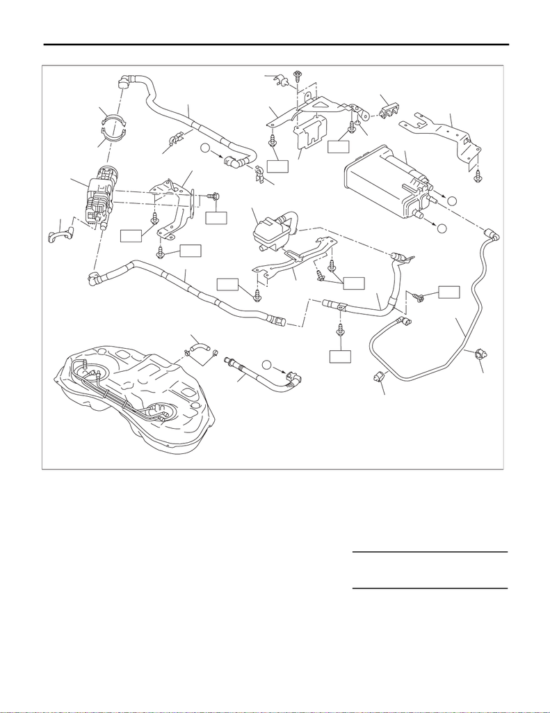

FU(STI)-10

General Description

FUEL INJECTION (FUEL SYSTEMS)

• Fuel line 2

(1) Vent hose (11) Purge tube (20) Canister bracket B

(2) Clip (12) Tube clamp (21) Tube clamp

(3) Vent tube (13) Clamp B (22) Clip

(4) Harness (14) Clamp A (23) Canister bracket C

(5) Leak check valve ASSY (15) Drain tube B (24) Canister

(6) Leak check valve bracket (16) Tube clamp

(7) Drain tube A (17) Tube clamp Tightening torque: N·m (kgf-m, ft-lb)

(8) Drain filter (18) Canister bracket A T1: 5.4 (0.6, 4.0)

(9) Drain bracket (19) Tube clamp T2: 7.5 (0.8, 5.5)

(10) Drain pipe

*1 The canister bracket cannot be separated from the canister. Therefore, be sure to replace both of them with new ones when

replacing the canister or canister bracket.

*2 The drain filter cannot be separated from the drain bracket. Therefore, be sure to replace both of them with new ones when

replacing the drain bracket or drain filter.

FU-08475

(1)

(2)

(3)

(7)

(4)

(5)

(6)

T2

T1

T2

T2

T2

(8)

(9)

2

2

(10)

T2

T2

(11)

(12)

(12)

(13)

(14)

(15)

(16)

(17)

(18)

(19)

(20)

(21)

T2

T2

(22)

1

1

(23)

(24)

1*

A

A

B

B

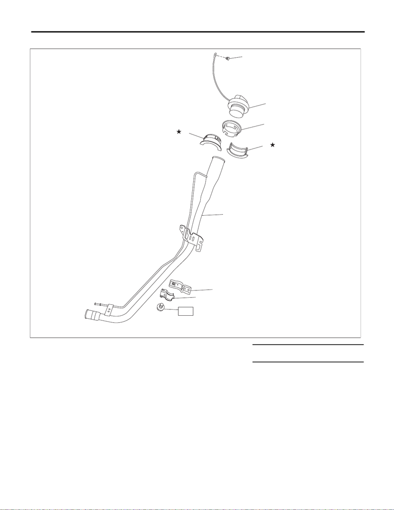

FU(STI)-11

General Description

FUEL INJECTION (FUEL SYSTEMS)

6. FUEL FILLER PIPE

(1) Fuel filler pipe ASSY (5) Fuel filler cap Tightening torque: N·m (kgf-m, ft-lb)

(2) Neck holder A (6) Clip T: 7.35 (0.7, 5.4)

(3) Neck holder B (7) Upper bracket

(4) Fuel filler pipe protector (8) Lower bracket

FU-08448

T

(1)

(2)

(3)

(4)

(5)

(6)

(7)

(8)

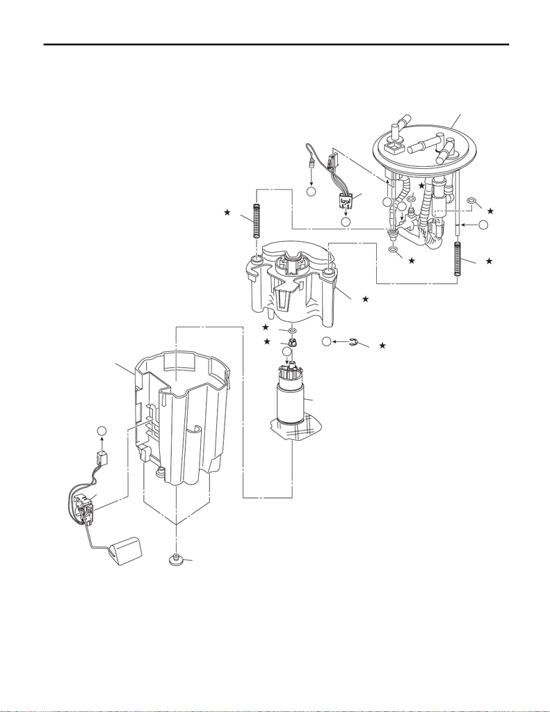

FU(STI)-12

General Description

FUEL INJECTION (FUEL SYSTEMS)

7. FUEL PUMP

(1) Sub tank bracket ASSY (5) Spring (9) Pump ASSY

(2) O-ring (6) Fuel filter (10) Sub tank

(3) O-ring (7) Clip (11) Cushion

(4) Fuel pump harness (8) Spacer (12) Fuel level sensor

* When removing the cushion from the fuel chamber assembly, replace it with a new part.

(2)

(1)

(2)

(3)

(4)

(5)

(5)

(6)

(2)

(8)

(9)

(10)

(11)

(7)

FU-08389

(12)

C

C

A

B

B

A

D

D

[figure not shown]

FU(STI)-13

General Description

FUEL INJECTION (FUEL SYSTEMS)

C: CAUTION

• Prior to starting work, pay special attention to the following:

1. Always wear work clothes, a work cap, and protective shoes. Additionally, wear a helmet, protective

goggles, etc. if necessary.

2. Protect the vehicle using a seat cover, fender cover, etc.

3. Prepare the service tools, clean cloth, containers to catch grease and oil, etc.

• Place “NO OPEN FLAMES” signs near the working area.

• Prepare a container and cloth to prevent scattering of fuels when performing work where fuels can be

spilled. If the oil spills, wipe it off immediately to prevent from penetrating into floor or flowing out for environ-

mental protection.

• Vehicle components are extremely hot immediately after driving. Be wary of receiving burns from heated

parts.

• When performing a repair, identify the cause of trouble and avoid unnecessary removal, disassembly and

replacement.

• Before disconnecting connectors of sensors or units, be sure to disconnect the ground cable from battery.

• Always use the jack-up point when the shop jacks or rigid racks are used to support the vehicle.

• Remove contamination including dirt and corrosion before removal, installation, disassembly or assembly.

• Keep the removed parts in order and protect them from dust and dirt.

• All removed parts, if to be reused, should be reinstalled in the original positions with attention to the correct

directions, etc.

• Bolts, nuts and washers should be replaced with new parts as required.

• Follow all government and local regulations concerning disposal of refuse when disposing fuel.

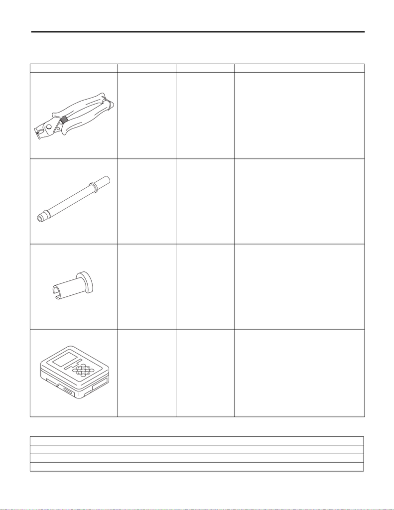

FU(STI)-14

General Description

FUEL INJECTION (FUEL SYSTEMS)

D: PREPARATION TOOL

1. SPECIAL TOOL

2. GENERAL TOOL

ILLUSTRATION TOOL NUMBER DESCRIPTION REMARKS

18353AA000 CLAMP PLIERS • Used for removing and installing the PCV

hose.

• This tool is made by the French company

CAILLAU. (code) 54.0.000.205

To make it easier to obtain, it has been provided

with a tool number.

18471AA000 FUEL PIPE

ADAPTER

Used for draining fuel.

42099AE000 QUICK CONNEC-

TOR RELEASE

Used for removing the quick connector.

1B022XU0 SUBARU SELECT

MONITOR III KIT

Used for draining fuel and each inspection.

TOOL NAME REMARKS

Circuit tester Used for measuring resistance and voltage.

Oscilloscope Used for inspecting the waveform of each sensor.

Mighty Vac Used for inspecting the manifold absolute pressure sensor.

ST18353AA000

ST18471AA000

ST42099AE000

ST1B022XU0